# WHAT YOU NEED TO KNOW TO START LEARNING ALGEBRA

Author

Affiliation

Dr Jay H Klopper

Department of Biostatistics and Bioinformatics

[figure not shown]

## 1 Introduction

We use numbers every day of our lives. We count objects and we consider costs and spending. While counting usually involves the use of whole numbers, we also consider parts of the whole when we cut a pizza into slices. Pizza slices are fractions of the whole and we pay for the pizza using decimal numbers.

Reading the time on our devices, involves numbers. Time involves a very special kind of mathematics called modular arithmetic. If we go to bed at $10$ and sleep for $8$ hours, we know that $10+8=6$. Modular arithmetic is a mathematical topic that is challenging at first, yet we deal with it so effortlessly, when we use time.

Numbers are everywhere in the life sciences. We count, add, multiply, calculate means and standard deviations. The list is endless.

In this notebook, we explore basic number types and arithmetic as a foundation to exploring the use of algebra in public health and biomedical research in later notebooks. A proper foundation in algebra can be an enjoyable and simple task. Being comfortable with algebra will allow everyone who goes on to study statistics, to concentrate on the understanding of data and its analysis instead of being *afraid of* or *sparring with* the mathematics.

This notebook is full of examples and exercise problems. All the solution are included. They are initially hidden, but you can view them with a simple dropdown arrow. You can use the solutions to verify your own results or take a quick look when you get stuck.

## 2 Objectives for this notebook

In this set of notebook, we explore mathematics, and algebra in particular. While being able to use a pencil and paper is part of the visceral experience and understanding of mathematics, we live in an era of powerful computers in our pockets and software on our computers. The calculations in these notebooks will be laid out in detail. We will, though, also make use of modern technology to gain a level of familiarity. We will use technology to verify our results or to simply do the calculations for us. We will use modern technology as a tool to learn about and understand the mathematics. Technology is a companion to our pencils and paper.

Our technology partner will be the Python programming language. This is not a set of notebooks on Python and the material will not teach you how to become a Python programmer. It will simply serve as our calculator instead of the calculator on our phones. Along the way, though, we will come to realize how Python can help us build our intuition for the mathematics and how it helps us understand the mathematics. Python will be our teaching aid when we need it.

### 2.1 Learning objectives

- Appreciate your prior knowledge of numbers and realize how useful they are
- Cement your understanding of numbers that can be used in calculations required in research

### 2.2 Coding objectives

- Use Python as a simple calculator for arithmetical operations (add, subtract, multiply, divide, and so on)

## 3 Different types of numbers

We classify numbers into different categories. These categories are so distinct, that we give them special names and symbols.

### 3.1 Natural numbers

The simplest and most intuitive category is the counting numbers, called the **natural numbers**. We use the symbol $\mathbb{N}$ to denote all the natural numbers. To sound more like a mathematician, we say that all the natural numbers are elements or members of a set. A **set** is any collection of objects, such as all the toppings on a pizza. With respect to numbers, the elememts are just that, numbers.

Because we consider the different categories of numbers as sets, we use set notation to indicate the elements of a set. In the case of natural numbers, we have Equation 1.

$$\mathbb{N} = \{ 1,2,3,4, \ldots \}
\tag{1}$$

**Information**

*Mathematics* is a long word, so we will just use the word *math*. We are all mathematicians, so instead of referring to mathematicians, we will just refer to ourselves and use the words *us* and *we*.

In math, as shown in Equation 1, we put the elements of a set in curly braces. Each member (number) is separated by a comma. We also see a set of ellipses, $\ldots$. Intuitively, we read this as a continuation along, or, following the recipe of elements, before the ellipses. This indicates a continuation of the numbers. The numbers never stop. The $\ldots$ at the end of the list of elements indicate infinity. The members of $\mathbb{N}$ (meaning the set of natural numbers) go to infinity. We refer to the number of elements in $\mathbb{N}$ as the **cardinality** or **size** of the set. In the case of $\mathbb{N}$, we say that the set is countably **infinite**. We can start the count, but it never ends.

In some cases, we add the number (element) $0$ to the natural numbers. To avoid any confusion, we use the symbol $\mathbb{N}_{0}$ when we refer to the set of natural numbers that include $0$, shown in Equation 2.

$$\mathbb{N}_{0} = \{ 0,1,2,3,4, \ldots \}
\tag{2}$$

In many cases, we want to consider a range of natural numbers. Age is a wonderful example in public health and biomedical research, that is, caputuring peoples’ age in years. In fancy terms, we would say *the unit of measurement of age is years*.

We consider a baby in its first year of life as being $0$ years old. Most humans do not live beyond $100$ years of age, let alone an infinite number of years. Maybe one day. As an android. Imagine that. Age can be expressed as a natural number in an interval. An interval (of ages) has a minimum and a maximum value. The minimum and maximum values for a set of age values are often quoted in research papers. In Equation 3, we use ellipses do denote the we follow the *recipe* up until a maximum number. In this case, $10$. We use the notation in Equation 3 simply to save some space.

$$\{ 1,2,3,4, \ldots , 10 \}
\tag{3}$$

To sound like mathematicians, we note that there is an order to the symbols that we use to denote numbers. We know that $5$ is larger than $2$. In fact ordering is an imporant and sophisticated topic in math. Even so, we have a natural intuition for order and make use of it all the time.

It is typical to use a lowercase letter as a symbol for an arbitrary number. For natural numbers, we typically use the symbols $i$, $j$, $k$, and $n$. In human research studies, we have a number of participants in a study. This number of people is referred to as the sample size. In many calculations, we would use the symbols $n$ to denote a sample size. The symbol $n$ takes on a specific value depending on how many people are in our study.

Finally, we visualize the natural numbers (at least the first few) as markers on the horizontal axis of the familiar Cartesian plane (mutually perpendicular lines), shown in Figure 1.

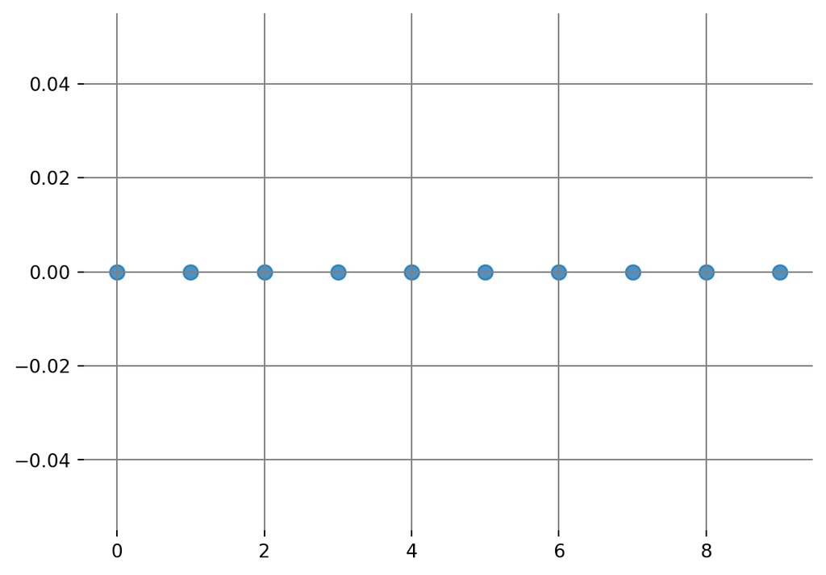

Figure 1: Natural numbers

### 3.2 Integers

The **integers** are also whole numbers. The set of integers includes $0$ and all the negative counterparts of the natrual numbers. In Equation 4, we list the integers. We make use of ellipses again to indicate infinity. This time, towards both positive and negative infinity.

$$\mathbb{Z} = \{ \ldots , -3,-2,-1,0,1,2,3, \ldots \}
\tag{4}$$

Arbitrary integers are usually denoted by lowercase letters such as $a$, $b$, $c$, $p$, and $q$.

As with natural numbers, there are an infinite number of integers, and we can also specify an interval or intervals of integers.

Both natural numbers and integers can be used in a computer language such as Python. In the code below, we simply type the natural number $3$, which is also an integer.

```python
3
```

```
3
```

In Python, we make use of objects. The $3$ that we just used, is an object. Objects have types. The type of a natural number or an integer is an `int`, short for integer. The `type` keyword is a Python function. Python uses entities called functions to perform tasks. A function has a name, followed by a pair of parentheses. We pass information to the function so that it can perform its task. The information is termed **arguments** or **parameters**. We can pass the number $3$ as argument to the type function.

```python
type(3)
```

```
int
```

We see that $3$ is indeed an `int` type.

### 3.3 Rational number

We use the term **rational number**, denoted by the symbol $\mathbb{Q}$, when we refer to ratios. A ratio involves division. We divide one integer into another integer. To make our lives easier, we write $12 \div 3$ as in Equation 5.

$$\frac{12}{3}
\tag{5}$$

The top number in Equation 5 is the **numerator** and the bottom number is the **denominator**.

While we had a numerator that was larger than the denominator in Equation 5, the word fraction is typically reserved for cases in which the numerator is smaller than the denominator. We consider a fraction of the whole. If we have are investigating $100$ people and $53$ of them are ill, we can concern ourlselves with the fraction of the whole (all $100$ people) that are ill. In Equation 6 we see the rational number that expresses the fraction of the whole in our example. Fractions are very, very usefull. In resaerch, we often use these fractions as proportions.

$$\frac{53}{100}
\tag{6}$$

Using arbitrary integers, $p$ and $q$, we write a generic rational number in Equation 7.

$$\frac{p}{q}
\tag{7}$$

Very importantly, we remember from school that we cannot divide by $0$, shown in Equation 8. We cannot divide a whole into $0$ parts.

$$\frac{p}{0} = \text{not defined}, \text{ so we write } \frac{p}{q}, \text{ where } q \ne 0
\tag{8}$$

Another well-known and often-used concept from school is the expression of rational numbers as decimals. We see a very simple example in Equation 9, where we divide $1$ by $2$, in other words, we divide the whole into $2$ and consider $1$ of the two parts, that is, a half of the whole.

$$\frac{1}{2} = 0.5
\tag{9}$$

Prices are displayed in decimal format. A baguette might cost $\$3.50$. The cost is $3$ whole dollars and one half of a dollar.

Some decimals have infinite *places* after the decimal point. A third, shown in Equation 10, is one such example. The bar over the $3$ indicates that the pattern of $3$’s continue forever.

$$\frac{1}{3} = 0.333333333 \ldots = 0.\bar{3}
\tag{10}$$

We will explore rounding in a later notebook. It is simply impractical to list a large number of decimal places in a research report. We truncate the number of decimals places by rounding. When to round off decimal palces in a calculation and how many decimal places to use comes up very often when we start to explore the statistical analysis of data.

### 3.4 Irrational numbers

An **irrational number** is a number that cannot be expressed as a rational number. We cannot write it by placing an integer in the numerator and in the denominator as with a rational number.

There are quintessential examples we used every day. The square root of $2$ or $\sqrt{2}$, $\pi$, and Euler’s number, $e$, are three beautiful examples.

We write decimal number approximations to these irrational numbers. These approximations have a few decimal places and then we terminate the list by rounding off (as discissed before). There is no fixed pattern to the decimal numbers as with Equation 10.

As you can imagine, there are an infinite number of irrational numbers.

### 3.5 Real numbers

All the integers, rational numbers, and irrational numbers together make up the real numbers. The set of real numbers are denoted by the symbol, $\mathbb{R}$.

As a collection of three catgeories of infinite numbers, there are an infinite number of real numbers. In many cases, most of the statistical analysis that we do in public health and in biomedical research involve real numbers.

Any rational, irrational, and real number that contains a decimal place is stored as a floating point number in Python. We use the `type` function for the interger $3$ before. Below, we do so for the number $3.0$.

```python
type(3.0)
```

```
float
```

We see that $3.0$ is a `float` type, which is short for floating point number (or decimal value).

## 4 Arithmetic

Arithmetic refers to operations we carry out on numbers. We are very familiar with most of these operations. Operations take numbers, combine them in some way, and return another number.

### 4.1 Addition

Additions adds two or more numbers.

Computers are very good with addition. In the code cell below, we see the addition of three numbers, $3+8+4$, using the Python `+` opeartor. Spaces between characters are not a requirement in Python, but they make the reading easier.

Arithmetic

```python
3 + 8 + 4
```

```
15
```

The result, $15$ is printed to the screen. See how easy Python is!

### 4.2 Subtraction

We are also very familiar with subtraction. Below, we subtract $4$ form $10$, or $10-4$.

```python
10 - 4
```

```
6
```

We see the result in $6$.

### 4.3 Multiplciation

Most computer languages use the star symbol, usually a part of the `8` key on most keyboards, to do multiplication. Below, we multiply $4$ and $3$, or $4 \times 3$.

```python
4 * 3
```

```
12
```

We see the result is $12$.

### 4.4 Division

Division gives us rational numbers. Rational numbers are very useful in that we use them as fractions and ratios. In a fraction or a ratio, we have a numerator and a denominator as we discussed in the section on rational numbers.

Most computer languages use the forward slash symbol, `/`, to indicate division as there is no divison symbol, $\div$, on a keyboard as there is on a calculator. Below, we calculate the expression in Equation 11, where $4$ is the numerator and $12$ is the denominator. In terms of division, we also use the term **divisor** for the denominator.

$$4 \div 12 = \frac{4}{12}
\tag{11}$$

```python
4 / 12
```

```
0.3333333333333333
```

The result is a third. Python expresses a third as a decimal approximation, showing the first few decimal places. As such, the results is of type `float`.

Division can itself involve division, in either the numerator or the denominator. In Equation 12, we note the familiar *flipping of the denominator*, where all of $a,b,c,d$ are integers and neither $b$ or $c$ are $0$.

$$\frac{\frac{a}{b}}{\frac{c}{d}} = \frac{a}{b} \times \frac{d}{c} = \frac{a \times d}{b \times c}
\tag{12}$$

**Task**

Calculate the following, all of which indicate division.

$$\begin{align}
&\frac{12}{3} \tag{a} \\ \notag \\
&\frac{4}{\frac{2}{7}} \tag{b}
\end{align}$$

**Solution**

$$\begin{align}
&\frac{12}{3} = 4 \tag{a} \\ \notag \\
&\frac{4}{\frac{2}{7}} = \frac{\frac{4}{1}}{\frac{2}{7}} = \frac{4}{1} \times \frac{7}{2} = \frac{28}{2} = 14 \tag{b}
\end{align}$$

We can use Python for these calculations. We start with (a).

```python
12 / 3
```

```
4.0
```

Now, we solve (b), making use of parentheses to determine the order of arithmetical operations, the next section in this chapter.

```python
4 / (2 / 7)
```

```
14.0
```

We will discover more about division and fractions later in this notebook.

### 4.5 Order of arithmetical operations

**Taks**

Calculate the following.

$$\frac{4 + 30 \times \frac{1}{2} + 1}{\frac{1}{10}} \tag{1}$$

**Solution**

$$\begin{align}
\frac{4 + 30 \times \frac{1}{2} + 1}{\frac{1}{10}} &= \frac{4 + 15 + 1}{\frac{1}{10}} \notag \\ \notag \\
&= \frac{20}{\frac{1}{10}} \notag \\ \notag \\
&= 20 \times 10 \notag \\ \notag \\
&= 200 \tag{1}
\end{align}$$

The full order of arithmetical operations is often remembered by the acronym PEMDAS, which dictates the sequence in which operations should be performed to accurately evaluate mathematical expressions. The order is as follows.

1. Parentheses (P): First, solve expressions inside parentheses or brackets.
2. Exponents (E): Next, evaluate powers or exponents.
3. Multiplication (M) and Division (D): Perform multiplication and division operations from left to right as they appear in the expression.
4. Addition (A) and Subtraction (S): Finally, perform addition and subtraction operations from left to right as they appear in the expression.

PEMDAS stands for Parentheses, Exponents, Multiplication, Division, Addition, and Subtraction.

### 4.6 Powers

Powers (or exponents) are a simple way to write multiplication of the same number by itself. Most of us are familiar with the fact that $3 \times 3 = 3^{2} = 9$. We see a general case in Equation 13 , where we multiply $a$ with itself $n$ times. Since $n$ is an arbirary natural number, we use ellipses, since we are not quite sure what value $n$ holds. That is why we use the term *generalization*.

$$a^{n} = a \times a \times a \times \ldots \times a, \; (n \text{ times multiplication})
\tag{13}$$

In Equation 13, we refer to $a$ as the base and $n$ as the power.

There are three special cases. When $n=1$ we have the original number $a$, and we write $a^{1}=a$. When $n=0$, we have that $a^{0}=1$. When $a=0$, then $0^{n}=0$. The only exception is when both $a$ and $n$ are $0$. In fact $0^{0}$ is not defined. By *not defined* we mean the answer does not exist. It is nonsensical to multiply $0$ by itself $0$ times.

**Task**

Calculate the following powers.

$$\begin{align}
&3^{4} \tag{a} \\ \notag \\
&5^{3} \tag{b} \\ \notag \\
&3^{5} \tag{c}
\end{align}$$

**Solution**

$$\begin{align}
&3^{4} = 3 \times 3 \times 3 \times 3 = 81 \tag{a} \\ \notag \\
&5^{3} = 5 \times 5 \times 5 = 125 \tag{b} \\ \notag \\
&3^{5} = 3 \times 3 \times 3 \times 3 \times 3 = 243 \tag{c} \\ \notag \\
\end{align}$$

In Python we use double asterisks, `**`. In the code cell below, we see the solutions to the example problems in the task above.

```python
# Problem (a)
3**4
```

```
81
```

```python
# Problem (b)
5**3
```

```
125
```

```python
# Problem (c)
3**5
```

```
243
```

Powers give us roots too. If we consider Equation 14, we have roots. Most notably, when $n=2$, we have the familiar square root and when $n=3$ we have the cube root.

$$a^{\frac{1}{n}} = \sqrt[n]{a}
\tag{14}$$

In general, we refer to the $n^{\text{th}}$ root. If the $n^{\text{th}}$ of $a$ is some number $x$, we mean that $x$ multiplied by itself $n$ times, gives us $a$.

**Task**

Calculate the following roots.

$$\begin{align}
&\sqrt[2]{9} \tag{a} \\ \notag \\
&\sqrt[3]{27} \tag{b}
\end{align}$$

**Solution**

$$\begin{align}
&\sqrt[2]{9} = 3 \text{, since } 3 \times 3 = 9\tag{a} \\ \notag \\
&\sqrt[3]{27} = 3 \text{, since } 3 \times 3 \times 3 = 27 \tag{b}
\end{align}$$

In Python, we have modules and packages that greatly expand the use of the language by importing extra functionality. Such modules and packages are imported using the `import` function.

```python
import math
```

Python has many inbuilt functions. Modules and packages add a lot more. The math module has many mathematical functions, and also constants.

Below, we use the `sqrt` function in the math module to calculate the square root of $9$. Since the `sqrt` function is in the imported math module, we have to reference the module by name. A period is used after the module name, before specifying the function name.

```python
math.sqrt(9)
```

```
3.0
```

With the equivalent notation in Equation 15, we can calculate roots using powers.

$$\sqrt[n]{a} = a^{\frac{1}{n}}
\tag{15}$$

We calculate $\sqrt[2]{9}$ using Python powers below, without using the math module.

```python
9**(1/2)
```

```
3.0
```

The final consideration with respect to powers can be seen in Equation 16, where $n$ is a natural number (meaning that it is positive).

$$a^{-n} = \frac{1}{a^{n}}
\tag{16}$$

In Equation 17 we see an example, where $a=2$ and $n=1$.

$$2^{-1} = \frac{1}{2^{1}} = \frac{1}{2}
\tag{17}$$

We confirm the results using Python. We place the negative pwoer inside a set of parentheses.

```python
2**(-1)
```

```
0.5
```

### 4.7 The irrational number $e$

When considering powers, we have the special case with a base $a=e$, where $e$ is Euler’s number. The math module holds values for constants such as $\pi$ and $e$. Below, we print out the first few decimal places of the irrational number $e$. Note that `e` is not a function, but a constant and we do not use parentesis.

```python
math.e
```

```
2.718281828459045
```

The math module also holds a function `exp`. The `exp` function allows us to calculate the exponent $e^{n}$. Passing $1$ as argument we have $e^{1}=e$.

```python
math.exp(1)
```

```
2.718281828459045
```

Now, we use $e^{3}$ as an example.

```python
math.exp(3)
```

```
20.085536923187668
```

With $a=e$ being a positive number, we have that $e^{x}$, where $x$ is any real number, is always positive, which we note in Figure 2. Irrespective of the value of $x$, the graph is always positive (above the $x$ axis).

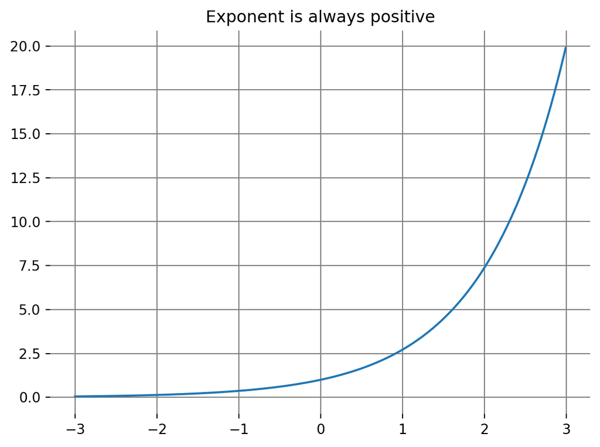

Figure 2: Exponent

Figure 2 is an example of exponetial growth.

### 4.8 Logarithms

Logarithms are interesting and useful operations that we perform on numbers. A logarithm (or log for short) has a base. We see a logarithm base $10$ in Equation 18.

$$\log_{10}{a} = b
\tag{18}$$

We intepret $b$ in Equation 19.

$$10^{b} = a
\tag{19}$$

As an example, we note Equation 20.

$$\log_{10}{100} = 2, \text{ since } 10^{2} = 100
\tag{20}$$

The `log10` function in the math module calculates calculate the log base $10$.

```python
math.log10(100)
```

```
2.0
```

A very useful base is $e$. We have a special name for $\log_{e}$, which is the natural logarithm, sometimes written as $\ln$. Many texbooks just use the word log, when they refer to the natural logarith and specify a base only when it is not $e$. Python does the same. The `log` function in the math module calculates the natural log. Below, we calculate $\log{\left( 10 \right)}$.

```python
math.log(10)
```

```
2.302585092994046
```

For any log base, we have that the log of $1$ is $0$. This is so because any number (other than $0$) raised to the power $0$ is $1$.

```python
math.log(1)
```

```
0.0
```

We cannot consider the log of $0$ or any negative number. As we have discussed with $a=e$, the any power of a positive number is always positive. We see this in Figure 3.

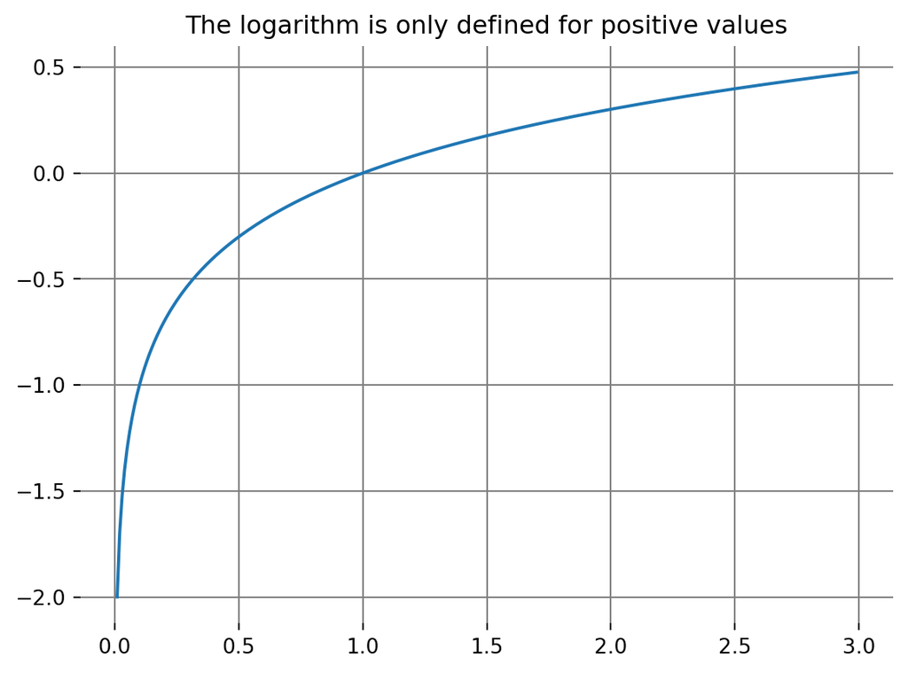

Figure 3: Logarithms are only defined for positive values

Figure 3 is an example of logarithmic growth.

## 5 Uses of division

### 5.1 Fractions and ratios

A ratio is calculated usig division. A fraction is also a ratio and is calculated using division. We do reserve the keyword fraction when the numerator is smaller than the denominator. In general, a ratio can have a numerator that is larger than the denominator. We see both, and the fact that we accomplish both calculations by division, in Equation 21. In either case, $a$ and $b$ are integers and we always have that $b \ne 0$. We also omit the case where $a=b$, which is simply $1$. We also remeber that if $a=0$, we have that our fraction or ratio is $0$.

$$\begin{align}
&\text{Ratio: }\frac{\text{numerator}}{\text{denominator}} \\ \\
&\text{Fraction: } \frac{a}{b}, \text{ where } a < b \text{ and } b \ne 0 \\ \\
&\text{Ratio: } \frac{a}{b}, \text{ where } a < b \text{ or } a > b \text{ or } a = b \\ \\
&\;\;\;\text{ and } b \text{ is never equal to } 0
\end{align}
\tag{21}$$

It is important to understand the basics of fractions and ratios. The basics include the *mechanics* of the parts of a fraction or a ratio and the comparison of different fractions and ratios.

We have seen that a fraction or a ratio has a numerator and a denominator. A fraction desribes a count of parts of a whole. By parts of the whole, we are referring to the denominator. The numerator describes how many of those parts we count.

Consider any shape, such as a square or a circle. We can divide a shape into equal parts. That would be $b$ equal parts. If $b=2$ then we have divided the shape into halves. If $b=4$, the we have divided the shape into $4$ equally sized parts. This is the value of the denominator.

The numerator, $a$, counts the number of $b$-parts of the whole. In Figure 4, we have divided the whole (of a circle) into $b=4$ equal parts (the denominator) and we consider $a=3$ parts (the numerator).

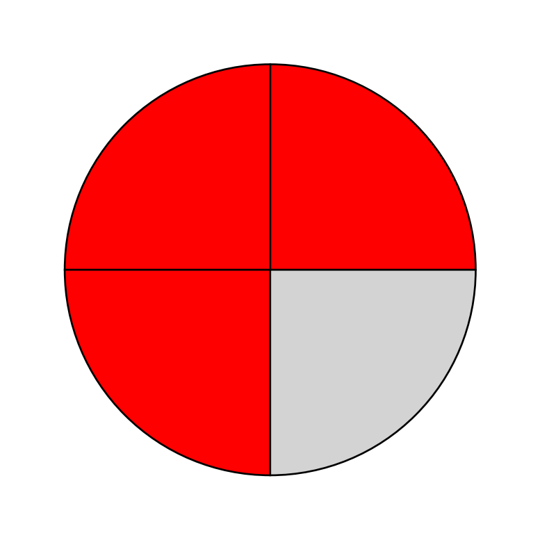

Figure 4: Three quarters of the whole

In Figure 5, we visualize the difference between three eights seven eights, seen in Equation 22. We keep $b=8$ fixed and compare $a=3$ to $a=7$.

$$\frac{3}{8} < \frac{7}{8}
\tag{22}$$

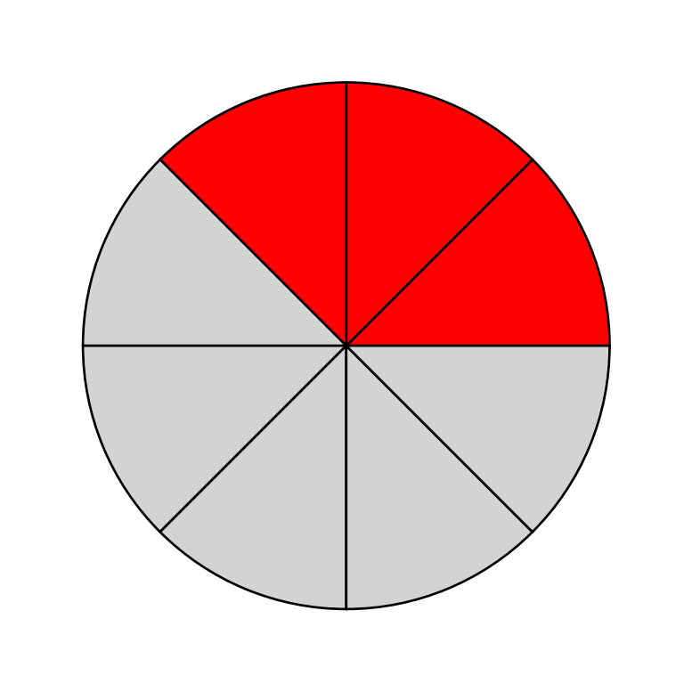

(a) Three eighths

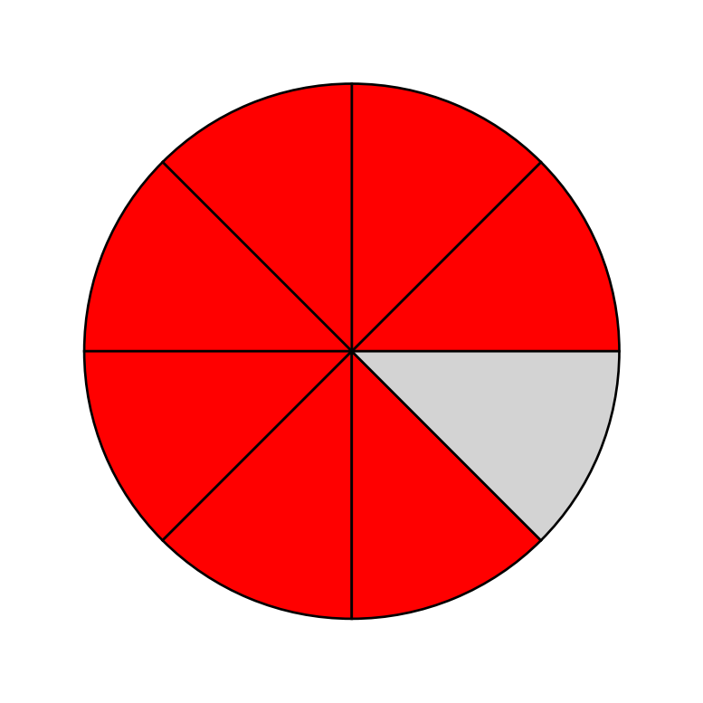

(b) Seven eighths

Figure 5: Eighths

With a good understanding of the parts of a fraction or a ratio, we consider the *mechanics*. By the mechanics we mean, changes in the values of $a$ or $b$, where we consider a change in one, while keeping the other constant.

If we keep $b$ constant and we increase $a$, we are counting more of the parts. The actual *overall* value that the fraction or ratio describes get bigger. If we decrease $a$, the we have fewer parts and and the overall value gets smaller.

In Figure 6, we visualize the difference between three eighths and three fifths, seen in Equation 23.

$$\frac{3}{8} < \frac{3}{5}
\tag{23}$$

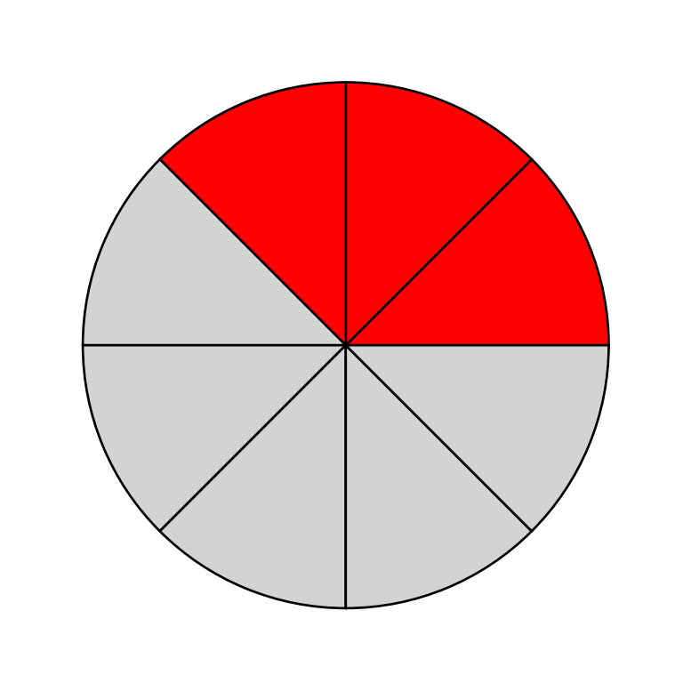

(a) Three eighths

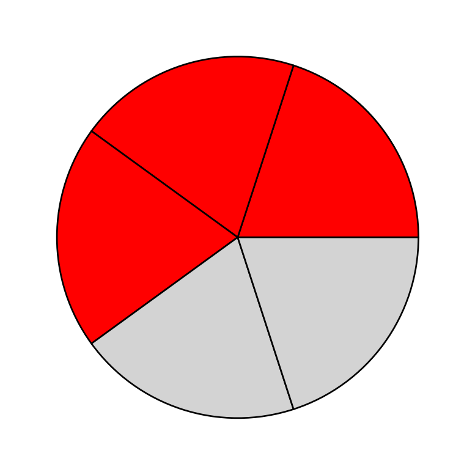

(b) Three fifths

Figure 6: Eighths and fifths

Understanding the mechanics, leads us to comparing fractions and ratios. When is one smaller or larger than the other?

$$1 = \frac{1}{1} = \frac{2}{2} = \frac{1206}{1206} = \frac{b}{b}
\tag{24}$$

Depending on the propblem, we can multiply by smaller values. Equation 26 should show the intuition.

$$\begin{align}
&\frac{3}{8} \text{ vs. } \frac{1}{4} \\ \\
&\frac{3}{8} \times \frac{1}{1} \text{ vs. } \frac{1}{4} \times \frac{2}{2} \\ \\
&\frac{3}{8} \text{ vs. } \frac{2}{8}
\end{align}
\tag{26}$$

**Task**

Compare the fraction and ratio below.

$$\begin{align}
&\frac{4}{9} \text{ vs. } \frac{5}{11} \tag{a} \\ \notag \\
&\frac{9}{4} \text{ vs. } \frac{17}{8} \tag{b}
\end{align}$$

**Solution**

$$\begin{align}
&\frac{4}{9} \times \frac{11}{11} = \frac{44}{99} < \frac{5}{11} \times \frac{9}{9} = \frac{45}{99} \tag{a} \\ \notag \\
&\frac{9}{4} \times \frac{2}{2} = \frac{18}{8} > \frac{17}{8} \tag{b}
\end{align}$$

### 5.2 Multiplication of fractions

The multiplication of fractions is quite simple. In Equation 27, we see two fractions, where each of $a,b,c$, and $d$ are integers, and neither $b$ nor $d$ are equal to $0$.

$$\frac{a}{b} \times \frac{c}{d} = \frac{a \times c}{b \times d}
\tag{27}$$

**Task**

Multiply the two fractions below.

$$\frac{3}{4} \times \frac{5}{6}$$

**Solution**

$$\frac{3}{4} \times \frac{5}{6} = \frac{3 \times 5}{4 \times 6} = \frac{15}{24}$$

### 5.3 The least common denominator

In Equation 26, we multiplied each fraction by $1$ and wrote that $1$ as a fraction containing the denominator of the other fraction. We can actually improve on this, especially when it comes to arithmetics using fractions. In Equation 28, we see the addition of two fractions. We rewrite each fraction by multiplying it by $1$, written as a fraction where the numerator and denominator are the denominator of the other fraction.

$$\begin{align}
\frac{3}{4} + \frac{5}{6} &= \left( \frac{3}{4} \times \frac{6}{6} \right) + \left( \frac{5}{6} \times \frac{4}{4} \right) \\ \\
&= \frac{18}{24} + \frac{20}{24}
\end{align}
\tag{28}$$

In Equation 29, we see an alternative way to solve Equation 28.

$$\begin{align}
\frac{3}{4} + \frac{5}{6} &= \left( \frac{3}{4} \times \frac{3}{3} \right) + \left( \frac{5}{6} \times \frac{2}{2} \right) \\ \\
&= \frac{9}{12} + \frac{10}{12}
\end{align}
\tag{29}$$

We have to determine whether these two solutions are equivalent. To do so, we have to consider the rule for the addition of fractions. It is so important that we place write it highlighted below.

**Rule for the addition of fractions**

Fractions can only be added if they have the same denominator. The addition of two fractions with the same denominator is shown below, where $c \ne 0$ and $a,b,$ and $c$ are integers.

$$\frac{a}{c} + \frac{b}{c} = \frac{a+b}{c}$$

We have seen that of the denominators are not the same, we can make use of multiplication by $1$ (using a cleverly chosen denominator).

**Task**

Add the fractions below.

$$\frac{9}{12} + \frac{10}{12}$$

**Solution**

$$\frac{9}{12} + \frac{10}{12} = \frac{19}{12}$$

In the previous task, we were asked to add two fractions. We note that it is the addition of the fractions in Equation 29. In Equation 30, we rewrite the solution.

$$\frac{19}{12} \times \frac{2}{2} = \frac{38}{24}
\tag{30}$$

**Task**

Add the fractions below.

$$\frac{18}{24} + \frac{20}{24}$$

**Solution**

$$\frac{18}{24} + \frac{20}{24} = \frac{38}{24}$$

The tasks have shown us that the two methods in Equation 28 and in Equation 29 are indeed similar. It brings to the important topic of the least common denominator.

We can *break down* or rewrite any integer into the multilication of other interegers. In more advanced algebra, we learn that these *other integers* (if the *break down* is complete) are all prime numbers (numbers that are only divisible by $1$ and themselves). We see some example in Equation 31, where we consider the integers that multiply to get $18$ and $9$.

$$\begin{array}{cccc}
18: & 2 & 3 & 3 \\
9: & & 3 & 3
\end{array}
\tag{31}$$

We have taken care to write similar numbers in the same columns. In Equation 32, we add a new line by *bringing down* or representing all the numbers.

$$\begin{array}{cccc}
18: & 2 & 3 & 3 \\
9: & & 3 & 3 \\
- & - & - & - \\
& 2 & 3 & 3
\end{array}
\tag{32}$$

$$\begin{align}
\frac{4}{9} + \frac{11}{18} &= \left( \frac{4}{9} \times \frac{2}{2} \right) + \left( \frac{11}{18} \right) \\ \\
&= \frac{8}{18} + \frac{11}{18} \\ \\
&= \frac{19}{18}
\end{align}
\tag{34}$$

We recognized that we do not have to perform the multiplication by rewriting $1$ as a fraction using the *other* fraction’s denominator. Since $18$ was the least common denominator, we only have to consider how to change the $9$ into an $18$ and that was mutiplying by $2$.

**Task**

Find the least common denominator for $12$ and $15$

**Solution**

Note the calculations below, to *convert* our denominators.

$$\begin{array}{ccccc}
12: & 2 & 2 & 3 & \\
15: & & & 3 & 5 \\
- & - & - & - & - \\
& 2 & 2 & 3 & 5
\end{array}$$

We have that $2 \times 2 \times 3 \times 5 = 60$. This is smaller than $12 \times 15 = 180$.

**Task**

Add the following fractions.

$$\frac{5}{12} + \frac{7}{15}$$

**Solution**

We have to *turn* $12$ into $60$ and $15$ into $60$. This is simple as shown below.

$$\frac{60}{12} = 5, \; \; \frac{60}{15} = 4$$

We have found the way to rewrite $1$ as a fraction.

$$\begin{array}{cccccc}
46: & 2 & & & & 23 \\
60: & 2 & 2 & 3 & 5 &
\end{array}
\tag{35}$$

We note that $2$ is the largest common multiple. We can divide both the numerator and denominator of the fraction in Equation 36.

$$\begin{align}
\frac{46}{60} &= \frac{46 \times \frac{1}{2}}{60 \times \frac{1}{2}} \\ \\
&= \frac{\frac{46}{2}}{\frac{60}{2}} \\ \\
&= \frac{23}{30}
\end{align}
\tag{36}$$

We cannot simplify this fraction any further. This is always so, when either of the numerator or the denominator contains a prime (unless they are both the same number, in which case we have a final solution of $1$).

### 5.4 Decimal values

We are familiar with the fact that we can write the fraction one-half as a decimal, $0.5$. We see some examples in Equation 37. By putting a bar over a repeating sequence (as in the last example of a third), we can simplify our notation.

$$\begin{align}
&\frac{1}{4} = 0.25 \\ \\
&\frac{1}{10} = 0.1 \\ \\
&\frac{5}{100} = 0.05 \\ \\
&\frac{1}{3} = 0.33333333333 \ldots = 0.\overline{3}
\end{align}
\tag{37}$$

Both in the case of a rational number with a repeating pattern of decimals, or with an irrational number, with an infinite random set of decimal values, computer can only deal with approximations. It can only calculate up to a certain number of decimal places. In mathematics we have an exact representation and a numeric approximation for these numbers. In Equation 38 we see exact representations and approximations. We use the equal symbol, $=$, when we have equality. We also see the approximate symbol, $\approx$, to denoted that we do not actually have an equality.

$$\begin{align}
&\pi \approx 3.14159265358979 \\
&\frac{1}{3} = 0.\bar{3} \approx 0.3333333333 \\
&\frac{5}{7} = 0.\overline{714285} \approx 0.71429
\end{align}
\tag{38}$$

### 5.5 Remainders

In a previous task, we have seen that a fraction or a ratio (or rational number) maintains the same numerical value if we divide both the numerator and denominator by the same number (remembering that we cannot divide by $0$). In Equation 39 we divide both numerator and denominator by the same non-zero number $k$.

$$\frac{p}{q} = \frac{\frac{p}{k}}{\frac{q}{k}}, \text{ where } p,k \ne 0
\tag{39}$$

In Equation 40, we note the equality between six-eights and a three-quarters.

$$\frac{6}{8} = \frac{\frac{6}{2}}{\frac{8}{2}} = \frac{3}{4}
\tag{40}$$

We could not divide $3$ and $4$ by another integer that divides both $3$ and $4$. By divides in this case, we mean, division without a remainder, or then, a remainder of $0$.

$$\frac{11}{4} = 2 \text{ with a remainder of } 3
\tag{41}$$

We have that $2 \times 4 + 3 = 8 + 3 = 11$, satisfying our division. In more general terms, we note Equation 42.

$$b = c a + r
\tag{42}$$

If $r=0$, we say that $a$ divides $b$ and $b=ca$, or then, $b$ is a constant multiple of $a$.

**Task**

Determine which of the following values of $a$ (where $a$ is an integer) divides $21$.

$$\begin{align}
&3 \tag{a} \\
&4 \tag{b} \\
&5 \tag{c} \\
&6 \tag{d} \\
&7 \tag{e} \\
&8 \tag{f} \\
&9 \tag{g} \\
&10 \tag{h} \\
\end{align}$$

**Solution**

$$\begin{align}
&3 \text{ divides } 21 \text{ since } \frac{21}{3} = 7 \tag{a} \\ \notag \\
&4 \text{ does not divide } 21 \text{ since } \frac{21}{4} = 5 \frac{1}{4} \tag{b} \\ \notag \\
&5 \text{ does not divide } 21 \text{ since } \frac{21}{5} = 4 \frac{1}{5} \tag{c} \\ \notag \\
&6 \text{ does not divide } 21 \text{ since } \frac{21}{6} = \frac{7}{2} = 3 \frac{1}{2} \tag{d} \\ \notag \\
&7 \text{ divides } 21 \text{ since } \frac{21}{7} = 3 \tag{e} \\ \notag \\
&8 \text{ does not divide } 21 \text{ since } \frac{21}{8} = 2 \frac{5}{8} \tag{f} \\ \notag \\
&9 \text{ does not divide } 21 \text{ since } \frac{21}{9} = \frac{7}{3} = 2 \frac{1}{3} \tag{g} \\ \notag \\
&10 \text{ does not divide } 21 \text{ since } \frac{21}{10} = 2 \frac{1}{10} \tag{h}
\end{align}$$

We can now use our knowledge of division to determine the smallest values in the numerator and denominator for any fraction. We state that we *simplify* the fraction. In terms of Equation 39, we always search for the largest integer that will divide both the numerator and denominator.

**Task**

Simplify the following fractions. Use only the positive solution for square roots. Note the last example contains knowledge of work that we have not covered.

$$\begin{align}
&\frac{4}{3} \tag{a} \\ \notag \\
&\frac{2}{8} \tag{b} \\ \\
&\frac{59}{177} \tag{c} \\ \\
&\frac{303}{22} \tag{d} \\ \\
&\frac{15}{100} \tag{e} \\ \\
&\frac{5^{2}-4}{7} - \sqrt{18-3^{2}} \tag{f} \\ \\
&\frac{\sqrt{12}}{\sqrt{3}} \tag{g}
\end{align}$$

**Solution**

In the cases $4 \div 3$, there is no number between $1$ and $3$ that divides both $4$ and $3$ and in the case of $303 \div 22$, we have no number from $1$ to $22$ that divides both $303$ and $22$ and we cannot simply the fractions any further.

## 6 Properties of real numbers

There are five important properties of real numbers. They are the commutative property, the assosciative property, the distriburive property, the identity property, and the inverse property.

### 6.1 Commutative property

The order of addition and multiplication is commutative. We are familiar with the fact that $3 + 4 = 4 + 3 = 7$ and $3 \times 4 = 4 \times 3 = 12$. This is not the case for subtraction and division. For instance $3-4 \ne 4-3$ and $3 \div 4 \ne 4 \div 3$.

In general, we have Equation 43.

$$\begin{align}
&a + b = b + a \\
&a \times b = b \times a
\end{align}
\tag{43}$$

### 6.2 Associative property

$$\begin{align}
&(a + b) + c = a + (b + c)
&(a \times b) \times c = a \times (b \times c)
\end{align}
\tag{44}$$

### 6.3 Distributive property

Addition does not distribute over muliplication. We have that $2 + (3 \times 4) = 2 + 12 = 14$. This is not the same as $(2+3) \times (2+4)=30$.

### 6.4 Indentity properties

The **identity property of addition** is $0$ since $a + 0 = 0 + a = a$. We do not change the value of $a$ by adding $0$.

The **identity proprety of multplication** is $1$, since $1 \times a = a \times 1 = a$. We do not change the value of $a$ when multiplying by $1$.

We note the identity properties in Equation 46.

$$\begin{align}
&a + 0 = 0 + a = a \\
& a \times 1 = 1 \times a = a
\end{align}
\tag{46}$$

### 6.5 Inverse properties

With respect to addition, we say that $-3$ is he **additive inverse** of $3$, since $3 + (-3) = 0$, the additive identity.

With respect to multiplication, we have that $\frac{1}{3}$ is the **multiplicative inverse** $3 \times \frac{1}{3} = 1$, the multiplicative identity.

In general, we have the additive inverse and the multiplicative inverses for $a$ in Equation 47. In the case of the multiplicative inverse, we have that $a \ne 0$.

$$\begin{align}
&a + (-a) = 0 \\
&a \times \frac{1}{a} = 1
\end{align}
\tag{47}$$

**Task**

Use the properties of real number to find the values of $x$ that make the following equations hold.

$$\begin{align}
&3 \times \frac{1}{x} = 1 \tag{1} \\ \notag \\
&2 + x = 0 \tag{2} \\ \notag \\
&4 + x = 5 + 4 \tag{3} \\ \notag \\
&3 \times 8 = x \times 3 \tag{4}
\end{align}$$

**Solution**

$$\begin{align}
&3 \times \frac{1}{x} = 1 \rightarrow x = 3 \tag{1} \\ \notag \\
&2 + x = 0 \rightarrow x = -2 \tag{2} \\ \notag \\
&4 + x = 5 + 4 \rightarrow x = 5 \tag{3} \\ \notag \\
&3 \times 8 = x \times 3 \rightarrow x = 8 \tag{4}
\end{align}$$

## 7 Algebraic expression

$$\frac{(3 \times x) + y + (-2)}{4}
\tag{48}$$

**Task**

List the constants and the variables in the following expressions.

$$\begin{align}
&3xy \tag{1} \\ \notag \\
&2 \pi r \tag{2} \\ \notag \\
&\sqrt{4 e} \tag{3}
\end{align}$$

**Solution**

| Expression | Constant(s) | Variables | Question |
| --- | --- | --- | --- |
| $3xy$ | 3 | $x,y$ | (1) |
| $2 \pi r$ | $2 \pi$ | $r$ | (2) |
| $\sqrt{4e}$ | $4, e$ | None | (3) |

We can substitute an appropriate value into a variable and calculate a value for an expression (if all the variables are given appropriate values).

**Task**

Subsitite the given values of the variables into the expressions and provide a value for the expression.

$$\begin{align}
&r=1 \text{ for } 2 \pi r \tag{1} \\ \notag \\
&x=2, \, y=7 \text{ for } \frac{14x}{y} \tag{2} \\ \notag \\
&x=3 \text{ for } \left( \frac{7}{x-3} \right)^{2} \tag{3}
\end{align}$$

**Solution**

$$\begin{align}
&r=1 \text{ for } 2 \pi r \rightarrow 2 \pi (1) = 2 \pi \tag{1} \\ \notag \\
&x=2, \, y=7 \text{ for } \frac{14x}{y} \rightarrow \frac{14 \times 2}{7} = 4 \tag{2} \\ \notag \\
&x=3 \text{ for } \left( \frac{7}{x-3} \right)^{2} \rightarrow \left( \frac{7}{3-3} \right)^{2} = \left( \frac{7}{0} \right)^{2} = \text{ undefined} \tag{3}
\end{align}$$

In the case of the last example, $x$ cannot take on a value of $3$, and we would exclude $3$ from the possible values of the variable $x$, and write $x \ne 3$.

Expressions are commonly used in formulas. We have already seen the formula for the circumeference of a circle, $2 \pi r$, where $r$ is the radius of the circle, in an example problem above.

In biostatitics, we often transform the value of a variabe, $X$, using the formula for $Z$, shown in Equation 49, where $\mu$ is the mean and $\sigma$ is the standard deviation.

$$\frac{X - \mu}{\sigma}
\tag{49}$$

For a variable value of $X=30$, a population mean, $\mu=20$, and a population standard deviation, $\sigma=2$, we would have Equation 50.

$$\frac{30-20}{2} = \frac{10}{2} = 5
\tag{50}$$

[Return to the home page](https://blogs.gwu.edu/juanklopper)